# Applied Computational Methods for Social Sciences

Lecture 21: Concluding Remarks — Spatial Data Programming with R

Bogdan G. Popescu

bogdan.popescu@johncabot.edu

John Cabot University

## Today

A look back at everything we’ve covered this semester — and where to go next.

## Learning Outcomes: Overview

Some of the learning outcomes in this course focused on:

- executing basic programming tasks in R (e.g. loops, conditional statements, while statements, etc.)
- understanding basic GIS (Geographic Information Systems) terms and concepts
- utilizing GIS for conducting spatial analyses.
- appreciating the design and structure of GIS as a decision-making tool.
- producing maps

## Skills Acquired

- clean and process data
- visualize data
- create interactive web-apps
- typeset: write visually appealing articles and presentations (R Quarto)

## Jobs where these skills are valued

- Data Scientist/Data Analyst
- GIS Analyst/GIS Specialist
- Environmental Scientist
- Market Research Analyst
- Remote Sensing Specialist
- Transportation Planner

## Use of R

R is also (more commonly) used in a variety of fields:

- Finance
- Academic research
- Government
- Retail
- Data Journalism
- Healthcare

## Companies that use R

Examples of companies which use R include

- Airbnb
- Microsoft
- Uber
- Facebook
- Google

## Additional Good resources for learning R

- **An Introduction to R**  
  https://cran.r-project.org/doc/manuals/r-release/R-intro.pdf  
  Complete introduction to base R
- **R for Data Science**  
  http://r4ds.had.co.nz/  
  Introduction to data analysis using R, focused on the tidyverse packages  
  Good substitute for Stata
- **Advanced R**  
  https://adv-r.hadley.nz/  
  Programming in R

## Good resources for learning R

- **Programming interactive R-apps using Shiny**  
  https://mastering-shiny.org/index.html  
  Useful for including interactive visualizations in web-pages
- **Markdown Basics**  
  https://quarto.org/docs/authoring/markdown-basics.html  
  Useful to create professionally-looking presentations and documents

## Books to Use: Data Analysis and Visualization

[Modern Statistics with R](https://www.modernstatisticswithr.com)

[R for Data Science](https://r4ds.hadley.nz)

[ggplot2](https://ggplot2-book.org/index.html)

## Books to Use: GIS

[Geocomputation with R](https://r.geocompx.org)

[Spatial Data Science](https://r-spatial.org/book/)

## Other useful Sources

- [A Guide on Data Analysis](https://bookdown.org/mike/data_analysis/)
- [Intro to GIS and Spatial Analysis](https://mgimond.github.io/Spatial/index.html)
- [Introduction to Spatial Data Programming with R](https://geobgu.xyz/r/index.html)

## Overview of Processing Vector Layers

`sf` was the main library that we worked with

It helped us deal with:

- **Numerical Operations** to calculate: Areas, Length, Distances, etc.
- **GIS Logical Operations**: Overlaps, Equals, Intersects, etc.
- **Geometry Operations**: Centroid, Buffer, Intersection, Union, Difference, etc.

## Overview of Processing Raster Layers

We performed geometric operation on rasters (pictures) with the `stars` package:

- **Accessing cell values** - as a matrix or as a dataframe, extracting pixels to points
- **Performing Raster algebra**: raster arirthmentic and logic
- **Changing the resolution and extent**: cropping, mosaicing, resampling, and reprojecting
- **Transforming Rasters**: to points and polygons

## Processing Raster Layers `stars`

Temperature in 1901

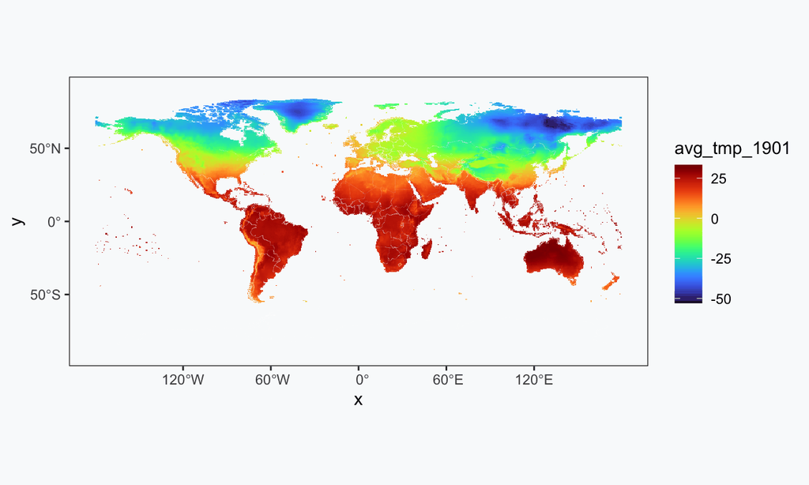

## Processing Raster Layers `stars`

Temperature in 2022

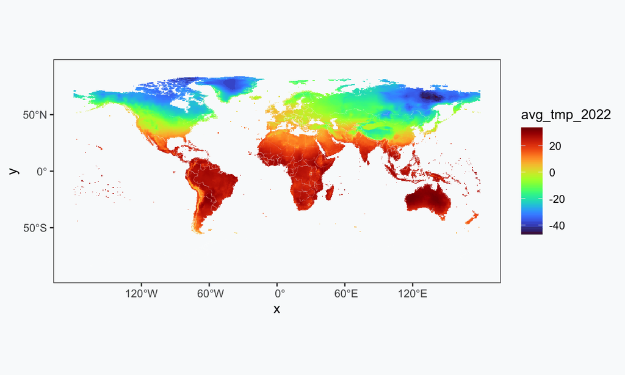

## Processing Raster Layers `stars`

Temperature difference between 2022 and 1901 > 4

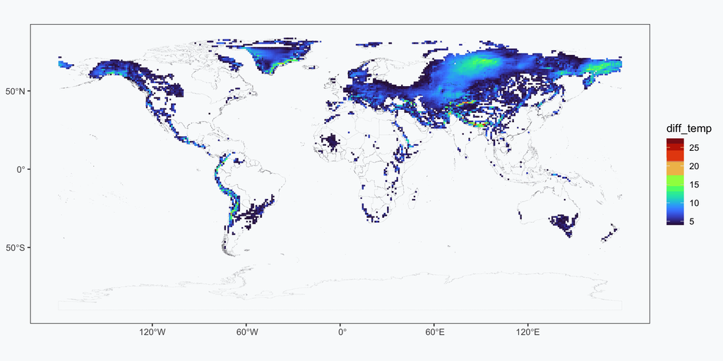

## Data visualization

- `ggplot2` is the library that allows to visualize data analysis results, but also to make maps
- `leaflet` is a library that allows us to make interactive maps
- `mapview` is a wrapper around `leaflet` automating the addition of: labels, popups, color scales, and common basemaps

## Supplementary Lectures

I encourage you to check out the supplementary lectures:

- [How to Make Shapefiles using QGIS](https://bgpopescu.net/files/teaching/big_data/supplem_lec1/lecture_qgis)
- [How to Make a Website using Quarto and GitHub](https://bgpopescu.net/files/teaching/big_data/supplem_lec2/lecture_github)

## Final Projects

This project offers an opportunity to showcase the acquired skills in manipulating spatial data and conducting meaningful analyses.

Tasks for the Project:

- acquire data either from the course materials or from external sources
- employ at least five GIS procedures in R such as: `st_join`, `st_centroid`, `st_area`, `st_distance`, `st_buffer`, `st_voronoi`, `st_union`, `st_combine`, `st_cast`, `st_intersection`, `st_difference`, dplyr for vector layer aggregation, `st_crop`, `st_rasterize`, `raster::aggregate`, etc.

## Final Projects

Or

Produce some descriptive visualizations (maps, barplots, scatterplots, boxplots) that tell the same story AND make a Github website (for data, you can explore https://ourworldindata.org)

- craft a well-structured two-page report (approx. 1500 words) containing an intro to the problem, objectives, data sources, methodology, results, and conclusion
- well-documented appendix (with comments and hashtags) with the R code for the GIS procedures.

## Grading Criteria for the project:

- Relevance
- Methodology: demonstration of at least five distinct GIS procedures in R (if applicable).
- Analysis
- Presentation
- Code Quality

For presentation and memo length, please peruse the examples provided.

## Instructions

Presentations will be on Friday, May 3rd in G.K.1.4, 09:00-11:30

Presentations should be 15 minutes.

Rehearse at least twice at home

Focus your presentation on the story

## Criteria for Presentation Grading

- Content Knowledge
- Organization
- Clarity of Expression
- Engagement with Audience
- Visual Aids
- Time Management

## Course Feedback and Evaluation

1. What are some aspects of the course that you liked?
2. What are areas for improvement?
3. Let’s do the course evaluations.

## What Have We Learned?

Thank you and good luck!